# Project1: Time Series

# Part1: Import the data

# Part2: Clean the data (manage missing values)

There are 7 missing values for data in factory f1 and 0 missing values for data in factory f2.

There are 2 missing timepoint values for data in factory f1 and 0 missing timepoint values for data in factory f2.

# Part3: Manage unexpected values

The unexpected or suspicious values are:  
1 unexpected values for data in factory f1 and 0 unexpected values for data in factory f2. We removed 1 unexpected values for data in factory f1 for later on analysis.

# Part4: Compute monitoring statistics for factory f1

Statistics table for SPC values for factory f1 is:

| timepoint | week | xbar | Range |
| --- | --- | --- | --- |
| 121 | 25 | 51.30 | 2.9 |
| 122 | 25 | 51.58 | 1.3 |
| 123 | 25 | 51.24 | 1.6 |
| 124 | 25 | 50.88 | 1.2 |
| 125 | 25 | 51.10 | 2.5 |
| 116 | 24 | 51.56 | 0.8 |
| 117 | 24 | 50.60 | 1.9 |
| 118 | 24 | 51.26 | 2.7 |
| 119 | 24 | 51.54 | 1.8 |
| 120 | 24 | 50.72 | 2.9 |

There are 123 number of rows in factory f1.  
Average across xbar and Range for factory f1 are: 51.0078049, 1.7365854

# Part5: Build Shewhart control charts for factory f1

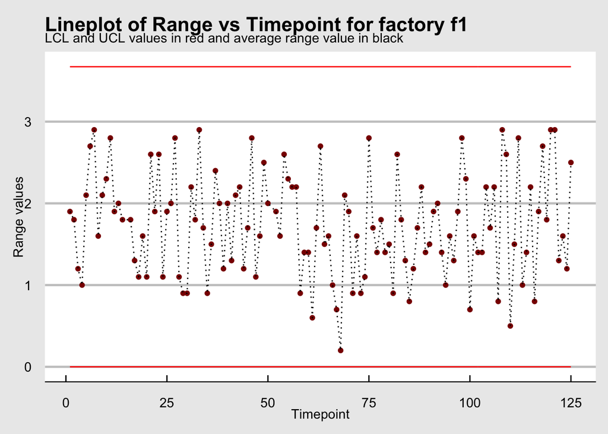

The R chart for range values for factory f1 shows all values within LCL and UCL.

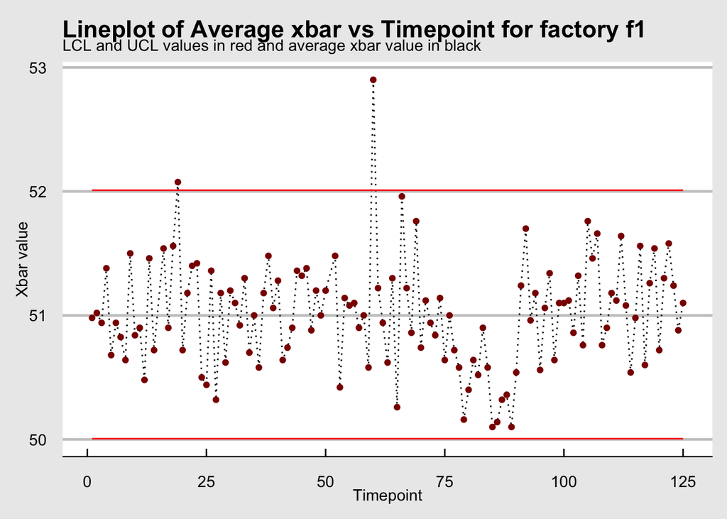

The Xbar chart for factory f1 shows few values outside LCL and UCL.

# Part6: Highlight special causes of variations

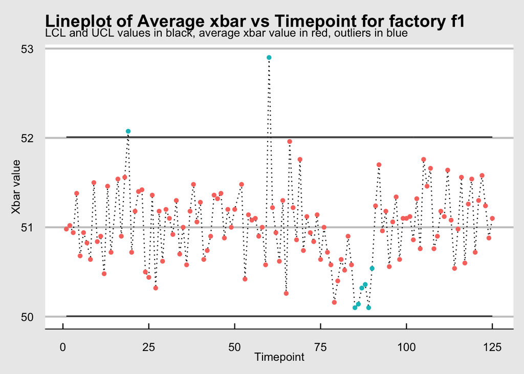

Looking at measurements from factory f1, there are 2 outliers (beyond control limits) and one instance of consecutive ten points on one side of the centerline.

# Part7: Build Shewhart control charts for factory f2

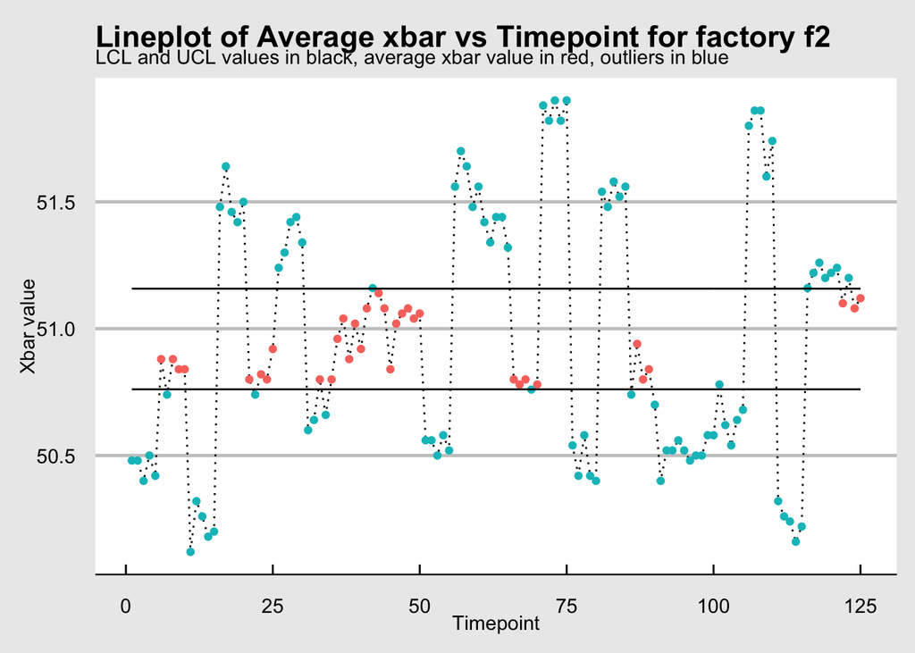

Looking at measurements from factory f2, there are multiple outliers (beyond control limits) and multiple instances of consecutive ten points on one side of the centerline.

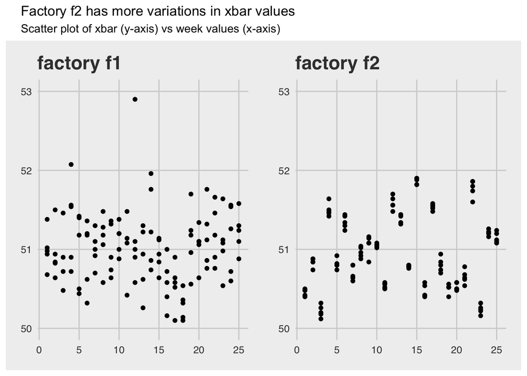

Factory 2 has more variations in value compared to factory f1. There seems to be some sort of systemic bias in measurements from factory f2.

# Part8: Redefining montoring data for factory f2

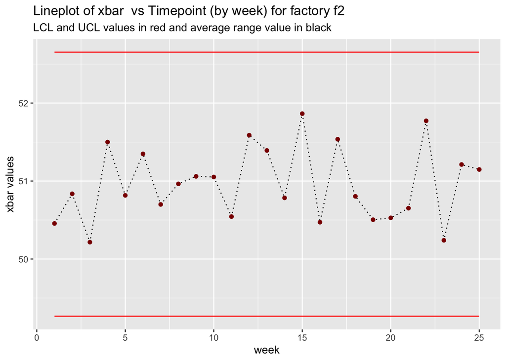

Looking at measurements from factory f2, average xbar value is within LCL and UCL

# Part9: Time series data looking at milk quality across months

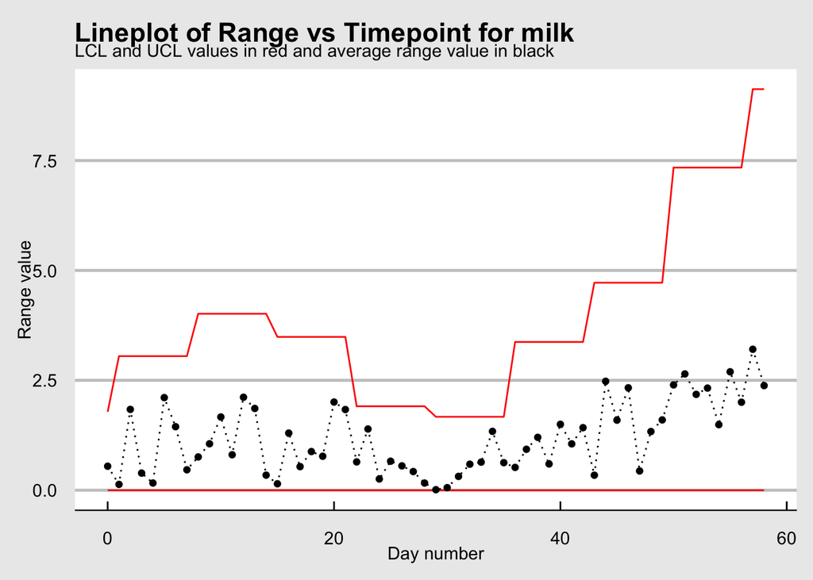

Looking at measurements from milk produced by cow per kg, its seems that average range values are within the range of LCL and UCL

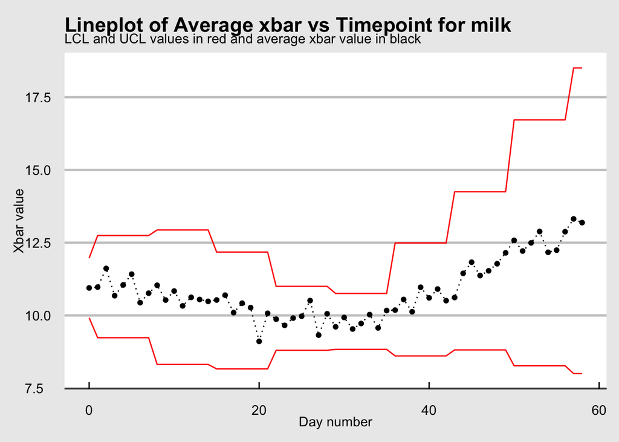

Looking at measurements from milk produced by cow per kg, its seems that average Xbar values are within the range of LCL and UCL. Looks like our cows, hopefully swiss cows are consistent in producing milk quantity.